# PSTAT 131 Final Project

Eric Liu

## Introduction

The goal of my final project is to build a machine learning model that is able to predict the annual salary of NBA players based on their game stats and several other variables, such as age, draft number, and other advanced game stats.

### What is the purpose of this model?

Unlike some professional sports leagues, there is a special rule of the annual salary of all players in each team. For all 30 teams in NBA, there is salary cap that limits the sum of annual salaries of all players signed by each team. For example, the current salary cap for the 2022-23 season is 123.655 million, so the total salary of all players signed by each NBA team cannot exceed this amount. However, the salary cap for NBA is soft. It means that each team can pay more salaries than the amount of the salary cap, but it has to pay certain amount of luxury tax, and tax rates vary based on the exceeding amount. Therefore, since each team needs to hire 12-15 players each season, it is vital to allocate their budgets wisely, and this model can provide more insight for team management during salary negotiations with players and allocate budget more reasonably.

### Data source

The data for this project is obtained from Kaggle(https://www.kaggle.com/datasets/aishjun/nba-salaries-prediction-in-20172018-season), and it is provided by a user name AI Shaojun. The data contains the annual salaries and other related variables of all NBA players during the 2017-18 season. The reason why I only chose the data of one season is that there players usually sign a several-year contract, so the annual salaries of most players are relatively stable in a 3-4 year period.

### Load packages and set seed

```r
library(tidyverse) # for EDA, model fitting, etc
library(tidymodels)
library(ggplot2) # for visualization
library(corrplot) # for correlation and correlation plot
library(janitor)     # for cleaning out our data
library(glmnet) # for ridge and lasso regression
library(xgboost) # for boosted tree
library(ranger) # for random forest
library(randomForest)
library(rpart.plot)  # for visualizing trees
library(kknn)
library(vip)         # for variable importance

#library(vembedr)     # for embedding links

library("yardstick") # for measuring certain metrics
tidymodels_prefer()

# set seed
set.seed(0)
```

## Load and clean the data

First of all, we will load and clean the data. We will also drop unimportant variables, check whether there are misssing values in each columns, and do any necessary change to the data to make it easer to view and use.

### Load the data

```r
# load data
nba_salary <- read_csv("data/2017-18_NBA_salary.csv")
head(nba_salary)
```

```
## # A tibble: 6 × 28
##   Player Salary NBA_C…¹ NBA_D…²   Age Tm        G    MP   PER `TS%` `3PAr`   FTr
##   <chr>   <dbl> <chr>     <dbl> <dbl> <chr> <dbl> <dbl> <dbl> <dbl>  <dbl> <dbl>
## 1 Zhou … 8.16e5 China        43    22 HOU      16    87   0.6 0.303  0.593 0.37
## 2 Zaza … 3.48e6 Georgia      42    33 GSW      66   937  16.8 0.608  0.004 0.337
## 3 Zach … 1.23e7 USA          19    36 SAC      59  1508  17.3 0.529  0.193 0.14
## 4 Zach … 3.20e6 USA          13    22 CHI      24   656  14.6 0.499  0.346 0.301
## 5 Zach … 3.06e6 USA          10    20 POR      62   979   8.2 0.487  0.387 0.146
## 6 Yogi … 1.31e6 USA          62    24 DAL      79  2238  11.5 0.543  0.489 0.141
## # … with 16 more variables: `ORB%` <dbl>, `DRB%` <dbl>, `TRB%` <dbl>,
## #   `AST%` <dbl>, `STL%` <dbl>, `BLK%` <dbl>, `TOV%` <dbl>, `USG%` <dbl>,
## #   OWS <dbl>, DWS <dbl>, WS <dbl>, `WS/48` <dbl>, OBPM <dbl>, DBPM <dbl>,
## #   BPM <dbl>, VORP <dbl>, and abbreviated variable names ¹NBA_Country,
## #   ²NBA_DraftNumber
```

### Tidy the data

Although the data we obtained is tidy, we still have several steps to do to make it easier to manipulate. First, we clean the names of the dataset, and then check its dimension.

```r
# clean names
nba_salary <- clean_names(nba_salary)
head(nba_salary)
```

```
## # A tibble: 6 × 28
##   player     salary nba_c…¹ nba_d…²   age tm        g    mp   per ts_pe…³ x3p_ar
##   <chr>       <dbl> <chr>     <dbl> <dbl> <chr> <dbl> <dbl> <dbl>   <dbl>  <dbl>
## 1 Zhou Qi    8.16e5 China        43    22 HOU      16    87   0.6   0.303  0.593
## 2 Zaza Pach… 3.48e6 Georgia      42    33 GSW      66   937  16.8   0.608  0.004
## 3 Zach Rand… 1.23e7 USA          19    36 SAC      59  1508  17.3   0.529  0.193
## 4 Zach LaVi… 3.20e6 USA          13    22 CHI      24   656  14.6   0.499  0.346
## 5 Zach Coll… 3.06e6 USA          10    20 POR      62   979   8.2   0.487  0.387
## 6 Yogi Ferr… 1.31e6 USA          62    24 DAL      79  2238  11.5   0.543  0.489
## # … with 17 more variables: f_tr <dbl>, orb_percent <dbl>, drb_percent <dbl>,
## #   trb_percent <dbl>, ast_percent <dbl>, stl_percent <dbl>, blk_percent <dbl>,
## #   tov_percent <dbl>, usg_percent <dbl>, ows <dbl>, dws <dbl>, ws <dbl>,
## #   ws_48 <dbl>, obpm <dbl>, dbpm <dbl>, bpm <dbl>, vorp <dbl>, and abbreviated
## #   variable names ¹nba_country, ²nba_draft_number, ³ts_percent
```

```r
# check dimension
dim(nba_salary)
```

```
## [1] 485  28
```

We can see that there are 485 observations and 28 variables. We obviously do not need all variables, so we need to drop unrelated variables and unimportant variables. Since the goal of the project is to predict salary, we can first drop unrelated variables including `nba_country` and `tm`(team). Then, based on my familiarity of basketball and NBA games, we can drop some unimportant variables. First, we can drop `g`(game played) and `mp`(minutes played) because `usg`(usage rate) is a better metric of player’s involvement calculated using `g`(game played) and `mp`(minutes played). Then, we can drop `x3p_ar`(3-point attempt rate) and `f_tr`(free throw rate) because `ts_percent`(true shooting percent) is a better metric of player’s shooting score ability calculated using `x3p_ar`(3-point attempt rate) and `f_tr`(free throw rate). Lastly, we can drop `ws`(win shares) because `ws_48`(win shares per 48 minutes) is a better metric since it measures player’s performance per game and it’s obtained by dividing `ws` 48 so we don’t need both.

```r
nba_salary <- nba_salary %>% select(-nba_country, -tm, -g, -mp, -x3p_ar, -f_tr, -ws)
```

Here are the descriptions of the key variables we will use as predictors, salary as the outcome, and players’ names for the convenience when analyzing:

- `player`: the name of the player
- `salary`: the annual salary of the player
- `nba_draft_number`: at which pick the player was drafted (1-62)
- `age`: the age of the player
- `per`: player efficiency rating (player’s positive accomplishments per minute)
- `ts_percent`: true shooting percentage (player’s shooting efficiency per game)
- `orb_percent`: offensive rebound percentage (estimate of the percentage of available offensive rebounds a player grabbed)
- `drb_percent`: defensive rebound percentage (estimate of the percentage of available defensive rebounds a player grabbed)
- `trb_percent`: total rebound percentage (estimate of the percentage of available total rebounds a player grabbed)
- `ast_percent`: assist percentage (estimate of the percentage of teammate field goals a player assisted)
- `stl_percent`: steal percentage (estimate of the percentage of steals a player performs)
- `blk_percent`: block percentage (estimate of the percentage of blocks a player performs)
- `tov_percent`: turnover percentage (estimate of the percentage of turnovers a player performs)
- `usg_percent`: usage rate (estimate of the percentage a player was involved in the game)
- `ows_percent`: offensive win shares (credit to a player based on his performance in offense)
- `dws_percent`: defensive win shares (credit to a player based on his performance in defense)
- `ws_48`: win shares per 48 minutes (player’s credit to team success per 48 minutes, obtained from WS divides 48)
- `obpm`: offensive box plus-minus (player’s offensive performance relative to the NBA average)
- `dbpm`: defensive box plus-minus (player’s defensive performance relative to the NBA average)
- `bpm`: box plus-minus (player’s performance relative to the NBA average)
- `vorp`: value over replacement player (estimate of the points per 100 TEAM possessions that a player contributed above a replacement-level (-2.0) player)

A complete codebook is included in the **data** subfolder.

Then, we need to check whether there are missing values

```r
nba_salary %>% map(~sum(is.na(.)))
```

```
## $player
## [1] 0
##
## $salary
## [1] 0
##
## $nba_draft_number
## [1] 0
##
## $age
## [1] 0
##
## $per
## [1] 0
##
## $ts_percent
## [1] 2
##
## $orb_percent
## [1] 0
##
## $drb_percent
## [1] 0
##
## $trb_percent
## [1] 0
##
## $ast_percent
## [1] 0
##
## $stl_percent
## [1] 0
##
## $blk_percent
## [1] 0
##
## $tov_percent
## [1] 2
##
## $usg_percent
## [1] 0
##
## $ows
## [1] 0
##
## $dws
## [1] 0
##
## $ws_48
## [1] 0
##
## $obpm
## [1] 0
##
## $dbpm
## [1] 0
##
## $bpm
## [1] 0
##
## $vorp
## [1] 0
```

Fortunately, we only 4 missing values in total, so we filter out observations with missing values. Then, We can have a check after dropping observations with missing values.

```r
# drop observations if ts_percent or tov_percent is missing
nba_salary <- nba_salary %>% drop_na(ts_percent)
nba_salary <- nba_salary %>% drop_na(tov_percent)

# check dimension
dim(nba_salary)
```

```
## [1] 483  21
```

Now, we have 483 observations and 21 variables in our data set.

To make salary easier to read, we can convert the salary column to be in millions and round numbers to have 3 digits after decimal point.

```r
nba_salary <- nba_salary %>%
  mutate(salary = round(salary / 1000000, digits = 3))
```

## Exploratory Data Analysis (EDA)

Now, since our dataset is tidy enough to use, we can continue to explore the feature of variables and correlation between variables.

### Salary

First, we can take a look at the distribution of the salary.

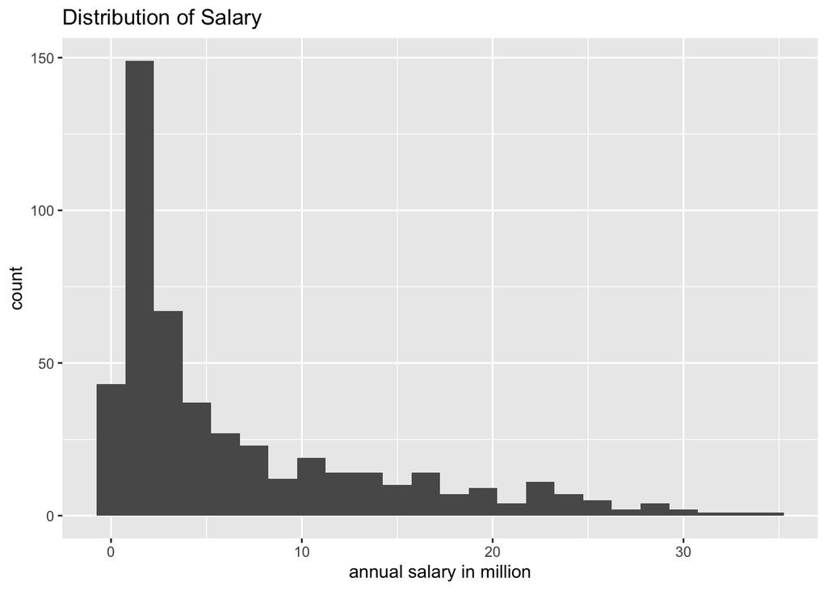

```r
# histogram of salary
nba_salary %>%
  ggplot() +
  geom_histogram(mapping = aes(salary), binwidth = 1.5) +
  labs(x = "annual salary in million", title = "Distribution of Salary")
```

Most players have an annual salary around 1-2 million, and there are extremely small amount players have relatively high salaries. Although it is a little surprising for me, it makes sense because most players are bench players who are paid on average, and only starter players and all-star level players are paid higher than the average. And only super-star players which are very rare, like Lebron James and Stephen Curry, are paid extremely high.

### Correlation

Then, let us have a look at the correlation map between variables.

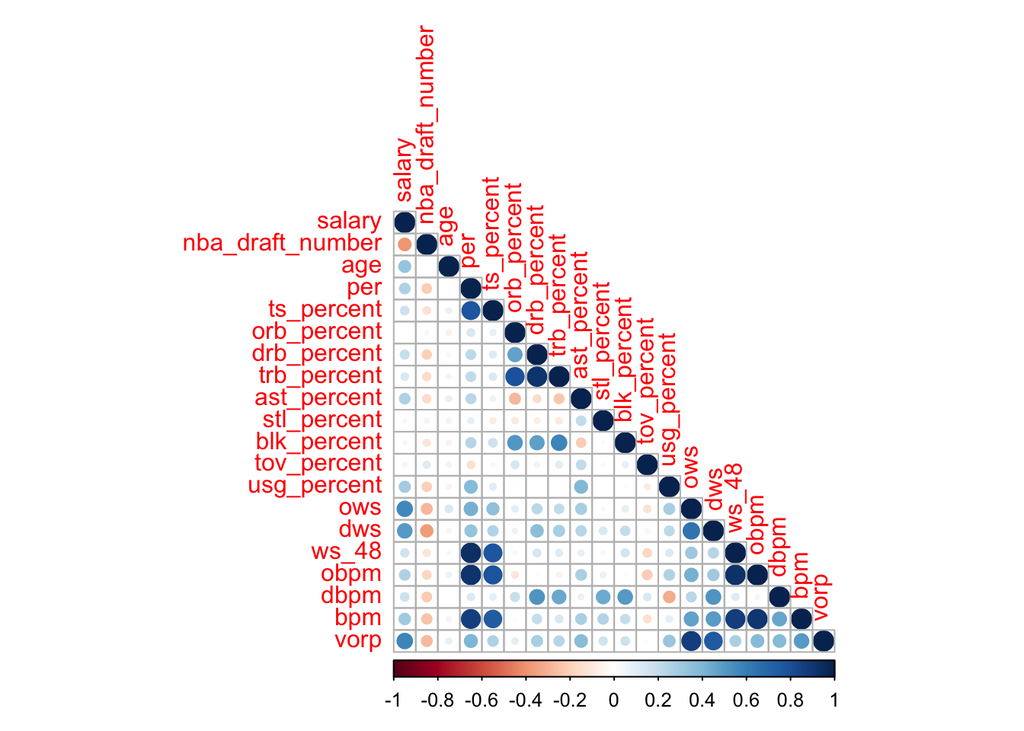

```r
# correlation map between all continuous variables
nba_salary %>%
  select(where(is.numeric)) %>%
  cor() %>%
  corrplot(method = "circle", type = "lower")
```

We can see that salary is negatively correlated with draft number and turnover rate, and it is positively correlated with all other variables. This result meets my expectation. If a player has lower draft number, he was drafted by the team earlier, so he was expected to have better performance and the team is willing to spend more money to attract and cultivate the player. Turnover rate(`ts_percent`) is a negative metric of player’s performance, so it also should be negatively correlated with the salary, but the correlation is very weak. Other variables are positive measurements of player’s performance, so it indicates that players with better performance tend to have higher salaries. If we take a close look at the extent of the correlation, we can also find that offensive win shares(`ows`), defensive win shares(`dws`), and value over replacement players(`vorp`) have relatively high correlation with salary. I guess it is because the team is more willing to pay more to players who can make more contribution and have better performance than the average.  
However, there are also some results that are surprising for me. First, age is positively correlated salary. Before seeing the plot, I assume that age should be negatively correlated, because older player tend to have lower physical performance, which limits their game performance, but it’s the opposite. Since age has very low correlations with other variables, I guess it is because older players can contribute more using their experience, so teams are willing to hire them with high salaries.  
In addition, there are strong correlations between variables. For example, there are strong correlations between player efficiency rating(`per`) and true shooting rate(`ts_percent`), win shares(`ws_48`), and box plus-minus(`bpm`). Therefore, we need to create interactions between those variables when creating the recipe.

### Draft Number

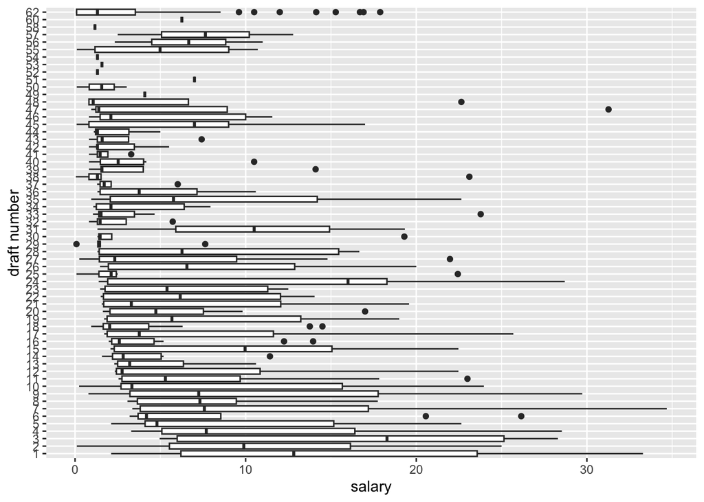

```r
# box plot of salary grouped by draft number
nba_salary %>%
  ggplot() +
  geom_boxplot(mapping = aes(x=salary, y=factor(nba_draft_number))) +
  labs(y = "draft number")
```

### Age

The following is a box plot of salary grouped by age, so we can further explore the relationship between salary and age.

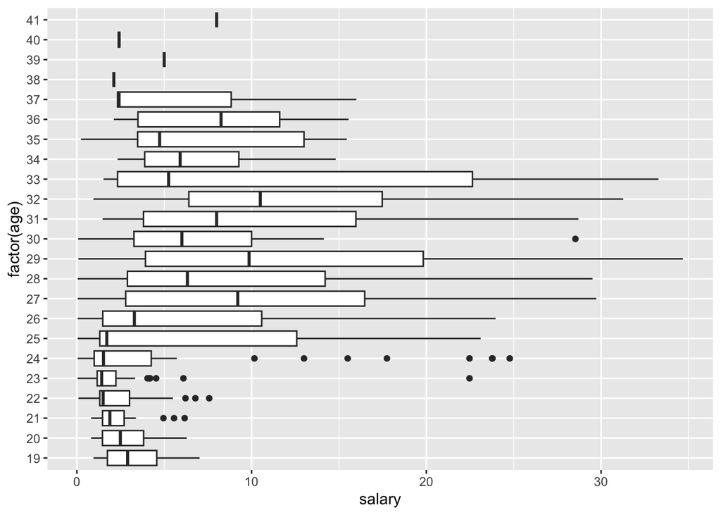

```r
# box plot of salary grouped by age
nba_salary %>%
  ggplot() +
  geom_boxplot(mapping = aes(x=salary, y=factor(age)))
```

### Positive Performance Metric

Now, we take a closer look at the relationship between salary and positive performance metrics. Since there are 15 positive performance metrics, I select `per`, `trb_percent`, `ast_percent`, `stl_percent`, `blk_percent`, and `vorp` to visualize, because they have a relatively low correlation with each other.

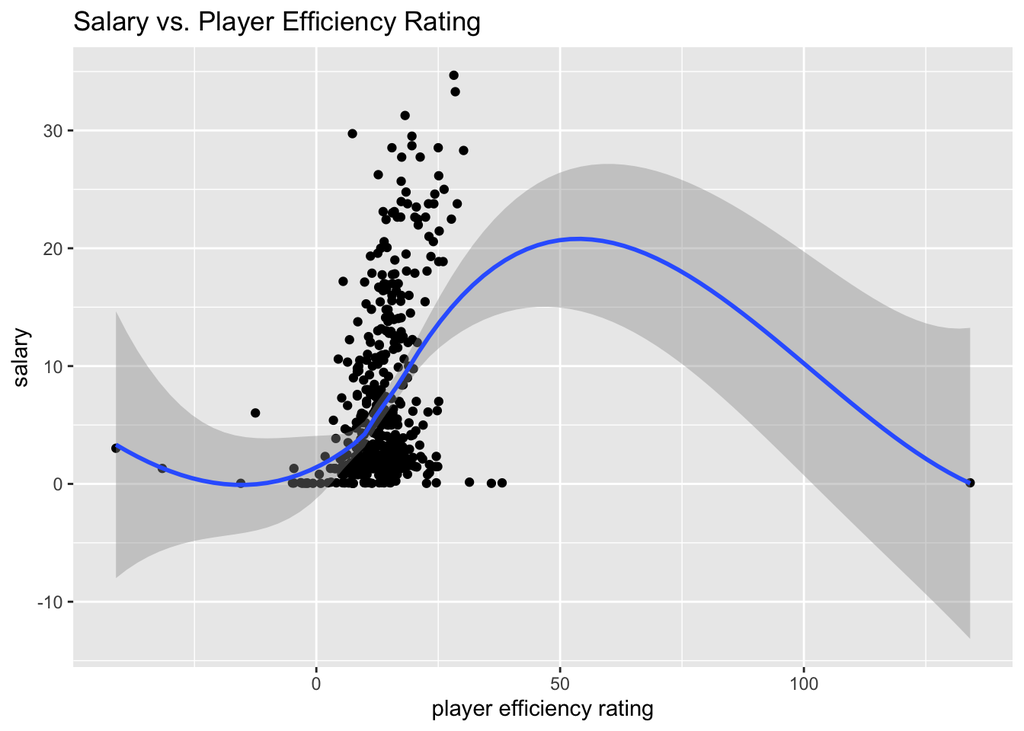

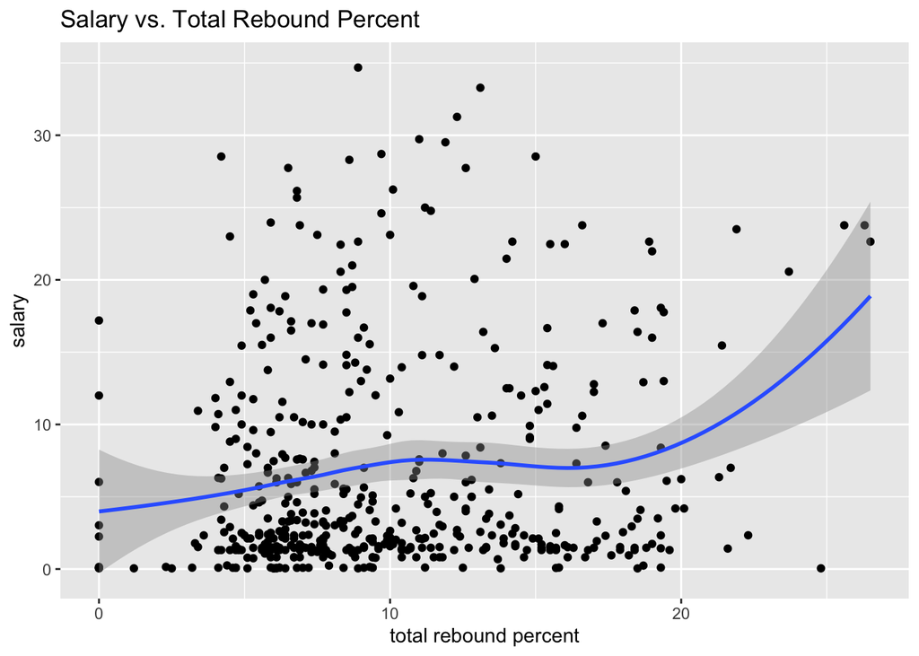

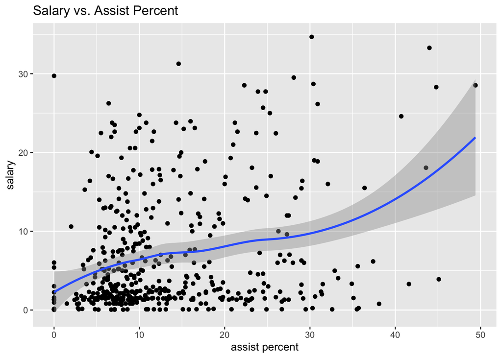

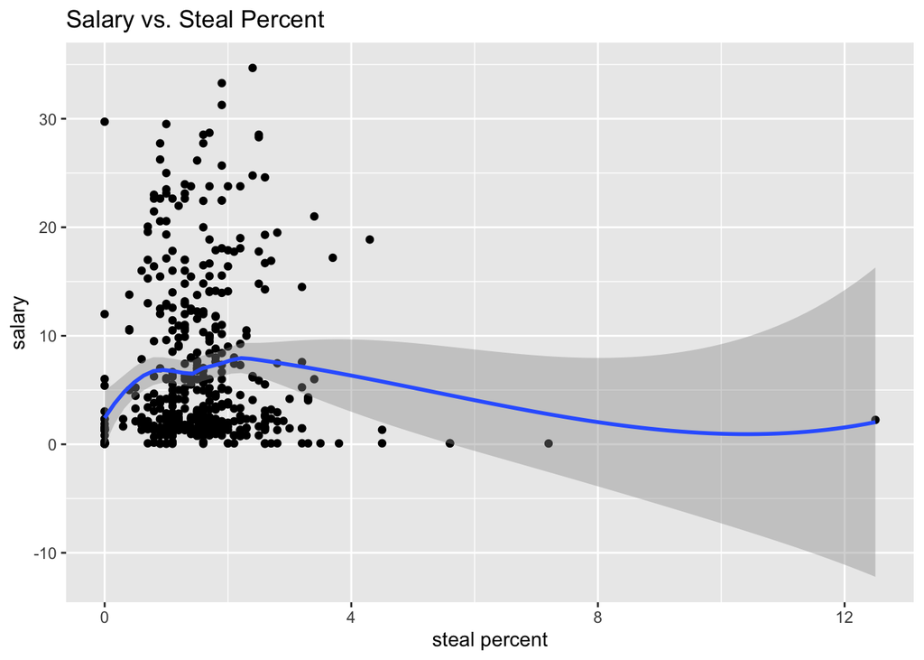

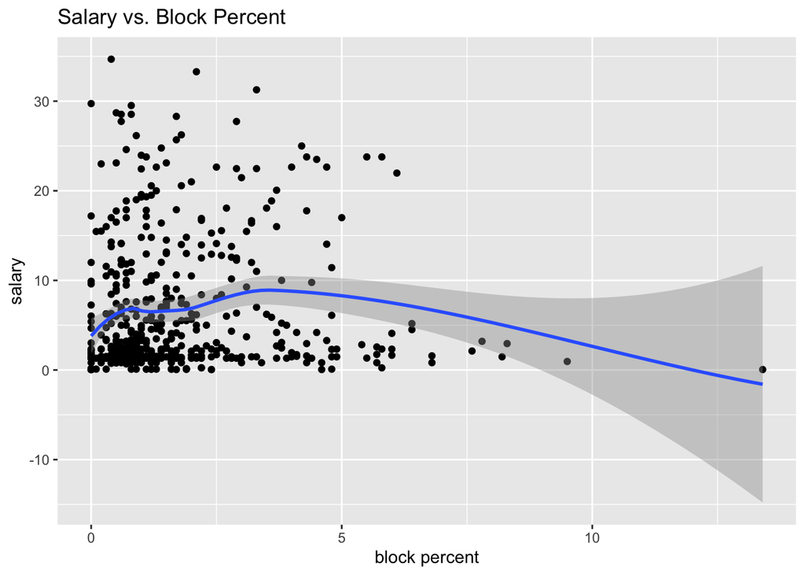

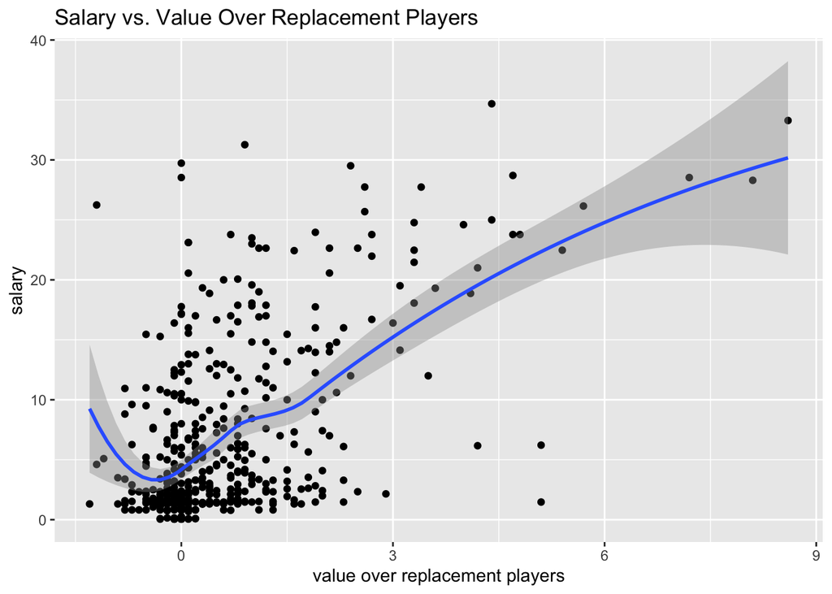

We can observe a clear positive correlation between salary and total rebound percent, assist percent, and value over replacement players. For player efficiency rating, steal percent, and block percent, there are outliers that affect the trend lines. However, if we ignore those outliers and focus on the major data points, we can see a very weak positive correlation.

### Negative Performance Metric

Then, here is a scatter plot of salary against turnover rate which is the only negative performance metric.

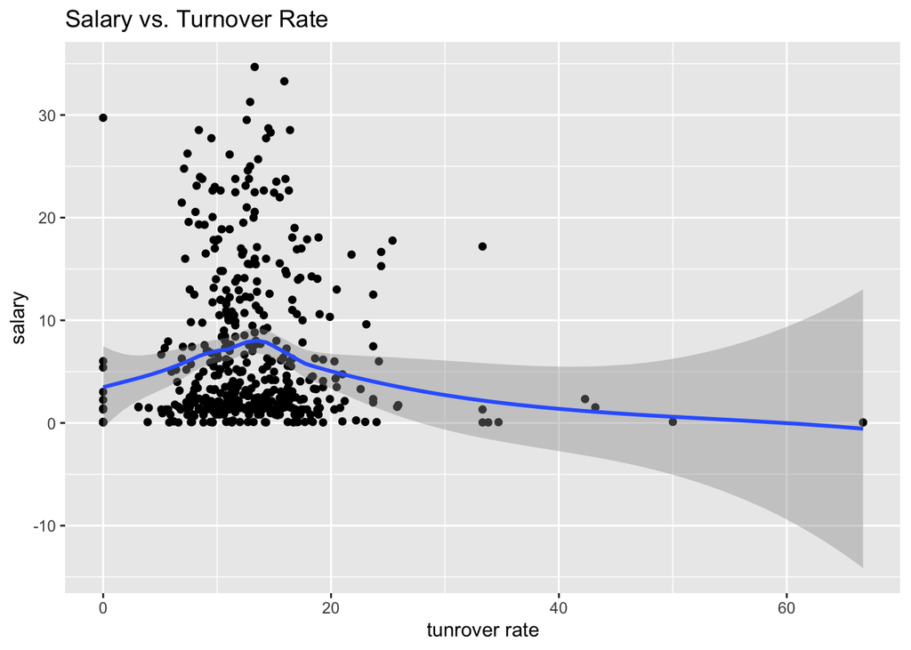

```r
# scatter plots of salary against turnover rate
nba_salary %>%
  ggplot(aes(tov_percent, salary)) +
  geom_point() +
  geom_smooth(method = "loess") +
  labs(
    title = "Salary vs. Turnover Rate", x = "tunrover rate"
  )
```

Most players have turnover rate between 5 and 20. In this range, the correlation between salary and turnover rate is very weak. For players who have turn over rate higher than 20, we can see that those players have lower salaries. This is corresponding to the result we observed from the correlation map. There is a extremely weak correlation between salary and turnover rate. For players who have extremely low turnover rate, I think its because they also have extremely less time on the court, so they have turnover rate nearly 0 and very low salaries.

### Usage Rate

Lastly, let us take a look at the relationship between salary and player’s usage rate.

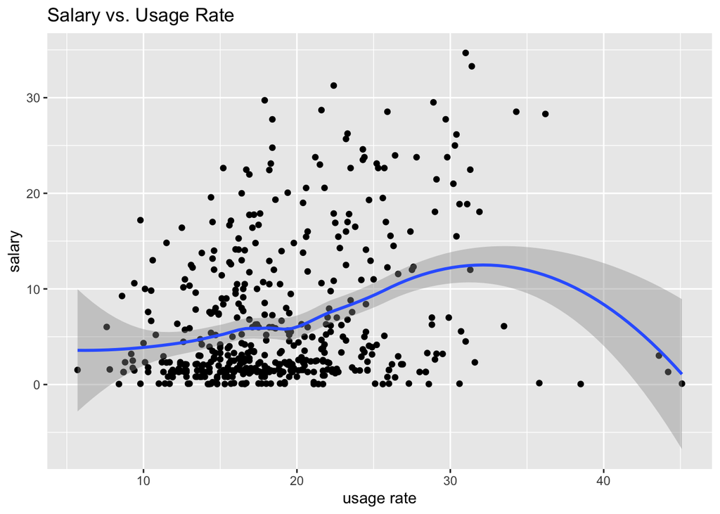

```r
# scatter plots of salary against usage rate
nba_salary %>%
  ggplot(aes(usg_percent, salary)) +
  geom_point() +
  geom_smooth(method = "loess") +
  labs(
    title = "Salary vs. Usage Rate", x = "usage rate"
  )
```

There is a weak positive correlation between salary and usage rate. We can notice that there are a few outliers on the right side. Several players have relatively high usage rate but very low salaries. I think it’s because the usage rate is the estimate of how much the player is involved when on the court. Some bench players are regularly on courts and have enough scoring attempts, but it does not necessarily mean that they make positive contribution when on the court. It only indicates they are sufficiently involved in the game.

## Set Up Models

Since we already explored the correlation between variables and had a general idea on how each predictor influences the outcome, we will move forward to set up our models. We will first split our data, then further split the training data into validation sets, and lastly create the recipe for models.

### Training/Testing Data Split

First we split the data into the training set and the testing set. Since there are 483 observations in total, to make training set have enough observations, I chose to split the data into 80/20. In addition, to make each dataset represent the whole population appropriately, we stratified the split on the outcome variable `salary`.

```r
# split the data
nba_split <- initial_split(nba_salary, prop = 0.8, strata = salary)
nba_train <- training(nba_split)
nba_test <- testing(nba_split)

# verify the number of observations
dim(nba_train)
```

```
## [1] 384  21
```

```r
dim(nba_test)
```

```
## [1] 99 21
```

After splitting the data into 80/20, we have 384 observations in the training set and 99 observations in the testing set.

### K-Fold Cross Validation

Next, we do the k-fold cross validation. To make each fold has enough observations, I chose k=5. Therefore, we randomly divide the training set into 5 folds of data with the equal size. Then, we treat one different group as the validation set each time. Repeating the process 5 times, we can obtain 5 estimates of the test error. By using k-fold cross-validation, we can have an estimate of the test error with far less bias. In addition, to make each fold more representative of the population, we also stratified on the outcome variable `salary`.

```r
# 5-fold cross validation
nba_folds <- vfold_cv(nba_train, v = 5, strata = salary)
nba_folds
```

```
## #  5-fold cross-validation using stratification
## # A tibble: 5 × 2
##   splits           id
##   <list>           <chr>
## 1 <split [306/78]> Fold1
## 2 <split [306/78]> Fold2
## 3 <split [307/77]> Fold3
## 4 <split [308/76]> Fold4
## 5 <split [309/75]> Fold5
```

### Create Recipe

Lastly, before fitting models, we create the recipe predicting the outcome variable `salary`. We include all variables other than `salary` and `player` in the dataset as predictors. Since all predictors are continuous, we do need to dummy code any predictor. Then, we include interactions between:

- player efficiency rating and true shooting percentage
- player efficiency rating and win shares per 48 minutes
- player efficiency rating and offensive box plus-minus
- player efficiency rating and box plus_minus
- true shooting percentage and win shares per 48 minutes
- true shooting percentage and offensive box plus-minus
- true shooting percentage and box plus_minus
- total rebound percentage and offensive rebound percentage
- total rebound percentage and defensive rebound percentage
- box plus-minus and win shares per 48 minutes
- box plus-minus and offensive box plus-minus
- value over replacement players and offensive win shares
- value over replacement players and defensive win shares

Lastly, we center and scale all predictors.

```r
# create recipe
nba_recipe <- recipe(salary ~ nba_draft_number + age + per + ts_percent + orb_percent + drb_percent + trb_percent + ast_percent + stl_percent + blk_percent + tov_percent + usg_percent + ows + dws + ws_48 + obpm + dbpm + bpm + vorp, data = nba_train) %>%
  step_interact(terms = ~ per:ts_percent) %>% # create interactions between variables
  step_interact(terms = ~ per:ws_48) %>%
  step_interact(terms = ~ per:obpm) %>%
  step_interact(terms = ~ per:bpm) %>%
  step_interact(terms = ~ ts_percent:ws_48) %>%
  step_interact(terms = ~ ts_percent:obpm) %>%
  step_interact(terms = ~ ts_percent:bpm) %>%
  step_interact(terms = ~ trb_percent:orb_percent) %>%
  step_interact(terms = ~ trb_percent:drb_percent) %>%
  step_interact(terms = ~ bpm:ws_48) %>%
  step_interact(terms = ~ bpm:obpm) %>%
  step_interact(terms = ~ vorp:ows) %>%
  step_interact(terms = ~ vorp:dws) %>%
  step_center(all_predictors()) %>% # center and scale all predictors
  step_scale(all_predictors())
```

## Build Models

I will try to fit several different models including:

- ridge regression
- lasso regression
- boosted tree
- random forest
- k nearest neighbors (KNN)

To fit each model, I will:  
1. specify model type, engine, and mode  
2. set up the workflow by adding model and recipe  
3. set the tuning grid and tune certain parameters  
4. compare the performance of models with different parameters and select the best performing model on the folds of each type  
5. compare the best performing models of each type, and select the model with best performance overall  
6. finalize the model

### Ridge Regression

We will fit a ridge regression model using **glmnet** engine. We specify `mixture = 0` to specify a ridge regression model and tune the parameter `penalty`.

```r
# ridge regression using glmnet engine, tune penalty
ridge <- linear_reg(penalty = tune(), mixture = 0) %>%
  set_mode("regression") %>%
  set_engine("glmnet")

# create workflow by adding recipe and model
ridge_workflow <- workflow() %>%
  add_recipe(nba_recipe) %>%
  add_model(ridge)

# create tuning grid for penalty
ridge_penalty_grid <- grid_regular(penalty(range = c(-5, 5)), levels = 50)

# fit models to folds
ridge_res <- tune_grid(
  ridge_workflow,
  resamples = nba_folds,
  grid = ridge_penalty_grid
)
```

The fitting process takes some time, so we save the result:

```r
save(ridge_res, ridge_workflow, file = "model/ridge.rda")
```

Assess the performance and select the best `penalty`:

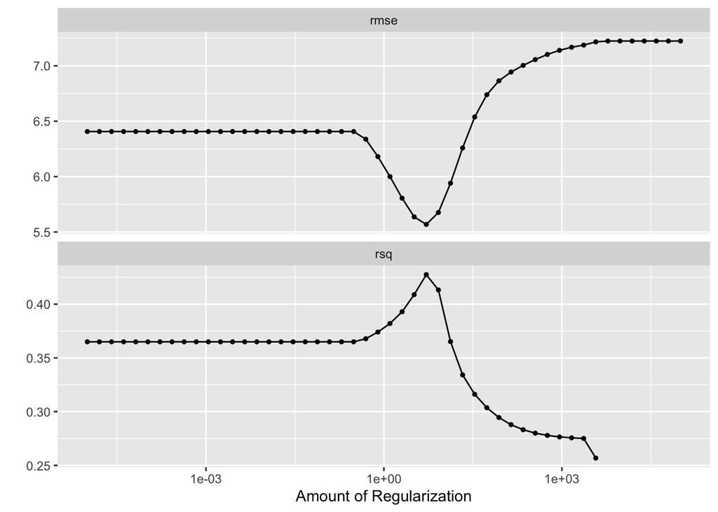

```r
# load the training result
load("model/ridge.rda")

# plot the result
autoplot(ridge_res)
```

```r
# show the best performing model
show_best(ridge_res, metric = "rmse")
```

```
## # A tibble: 5 × 7
##   penalty .metric .estimator  mean     n std_err .config
##     <dbl> <chr>   <chr>      <dbl> <int>   <dbl> <chr>
## 1    5.18 rmse    standard    5.57     5   0.207 Preprocessor1_Model29
## 2    3.24 rmse    standard    5.64     5   0.197 Preprocessor1_Model28
## 3    8.29 rmse    standard    5.68     5   0.199 Preprocessor1_Model30
## 4    2.02 rmse    standard    5.81     5   0.289 Preprocessor1_Model27
## 5   13.3  rmse    standard    5.94     5   0.222 Preprocessor1_Model31
```

```r
show_best(ridge_res, metric = "rsq")
```

```
## # A tibble: 5 × 7
##   penalty .metric .estimator  mean     n std_err .config
##     <dbl> <chr>   <chr>      <dbl> <int>   <dbl> <chr>
## 1    5.18 rsq     standard   0.427     5  0.0308 Preprocessor1_Model29
## 2    8.29 rsq     standard   0.413     5  0.0322 Preprocessor1_Model30
## 3    3.24 rsq     standard   0.409     5  0.0381 Preprocessor1_Model28
## 4    2.02 rsq     standard   0.393     5  0.0486 Preprocessor1_Model27
## 5    1.26 rsq     standard   0.382     5  0.0553 Preprocessor1_Model26
```

The best performing model of ridge regression is the model with `penalty`=5.18. It has the lowest `rmse` 5.57 and highest `rsq` 0.43.

### Lasso Regression

We will fit a ridge regression model using **glmnet** engine. We specify `mixture = 1` to specify a lasso regression model and tune the parameter `penalty`.

```r
# lasso regression using glmnet engine, tune penalty
lasso <- linear_reg(penalty = tune(), mixture = 1) %>%
  set_mode("regression") %>%
  set_engine("glmnet")

# create workflow by adding recipe and model
lasso_workflow <- workflow() %>%
  add_recipe(nba_recipe) %>%
  add_model(lasso)

# create tuning grid for penalty
lasso_penalty_grid <- grid_regular(penalty(range = c(-5, 5)), levels = 50)

# fit models to folds
lasso_res <- tune_grid(
  lasso_workflow,
  resamples = nba_folds,
  grid = lasso_penalty_grid
)
```

The fitting process takes some time, so we save the result:

```r
save(lasso_res, lasso_workflow, file = "model/lasso.rda")
```

Assess the performance and select the best `penalty`:

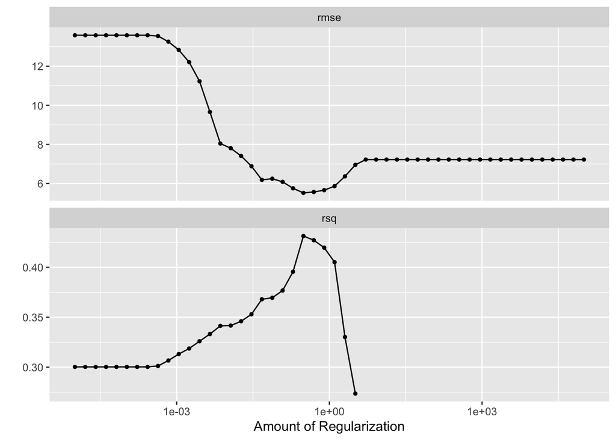

```r
# load the training result
load("model/lasso.rda")

# plot the result
autoplot(lasso_res)
```

```r
# show the best performing model
show_best(lasso_res, metric = "rmse")
```

```
## # A tibble: 5 × 7
##   penalty .metric .estimator  mean     n std_err .config
##     <dbl> <chr>   <chr>      <dbl> <int>   <dbl> <chr>
## 1   0.309 rmse    standard    5.52     5   0.223 Preprocessor1_Model23
## 2   0.494 rmse    standard    5.56     5   0.221 Preprocessor1_Model24
## 3   0.791 rmse    standard    5.66     5   0.221 Preprocessor1_Model25
## 4   0.193 rmse    standard    5.75     5   0.261 Preprocessor1_Model22
## 5   1.26  rmse    standard    5.86     5   0.215 Preprocessor1_Model26
```

```r
show_best(lasso_res, metric = "rsq")
```

```
## # A tibble: 5 × 7
##   penalty .metric .estimator  mean     n std_err .config
##     <dbl> <chr>   <chr>      <dbl> <int>   <dbl> <chr>
## 1   0.309 rsq     standard   0.431     5  0.0322 Preprocessor1_Model23
## 2   0.494 rsq     standard   0.427     5  0.0332 Preprocessor1_Model24
## 3   0.791 rsq     standard   0.420     5  0.0354 Preprocessor1_Model25
## 4   1.26  rsq     standard   0.405     5  0.0390 Preprocessor1_Model26
## 5   0.193 rsq     standard   0.396     5  0.0461 Preprocessor1_Model22
```

The best performing model of lasso regression is the model with `penalty`=0.31. It has the lowest `rmse` 5.52 and highest `rsq` 0.43, which is sligtly better than the ridge regression.

### Boosted Tree

We will fit a boosted tree model and tune `trees`.

```r
# boosted tree model
bt <- boost_tree(mode = "regression", trees = tune()) %>%
  set_engine("xgboost")

# create workflow by adding recipe and model
bt_workflow <- workflow() %>%
  add_recipe(nba_recipe) %>%
  add_model(bt)

# create tuning grid
bt_grid <- grid_regular(trees(range = c(10, 2000)), levels = 10)

# fit models to folds
bt_res <- tune_grid(
  bt_workflow,
  resamples = nba_folds,
  grid = bt_grid
)
```

The fitting process takes some time, so we save the result:

```r
save(bt_res, bt_workflow, file = "model/bt.rda")
```

Assess the performance and select the best `penalty`:

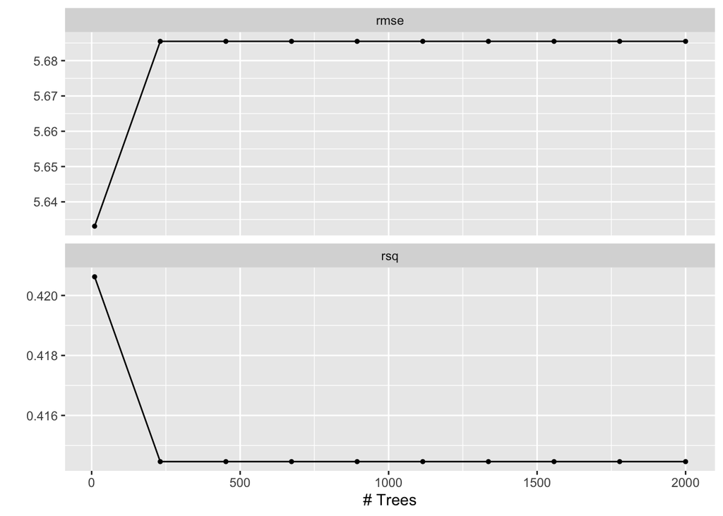

```r
# load the training result
load("model/bt.rda")

# plot the result
autoplot(bt_res)
```

```r
# show the best performing model
show_best(bt_res, metric = "rmse")
```

```
## # A tibble: 5 × 7
##   trees .metric .estimator  mean     n std_err .config
##   <int> <chr>   <chr>      <dbl> <int>   <dbl> <chr>
## 1    10 rmse    standard    5.63     5   0.232 Preprocessor1_Model01
## 2   231 rmse    standard    5.69     5   0.239 Preprocessor1_Model02
## 3   452 rmse    standard    5.69     5   0.239 Preprocessor1_Model03
## 4   673 rmse    standard    5.69     5   0.239 Preprocessor1_Model04
## 5   894 rmse    standard    5.69     5   0.239 Preprocessor1_Model05
```

```r
show_best(bt_res, metric = "rsq")
```

```
## # A tibble: 5 × 7
##   trees .metric .estimator  mean     n std_err .config
##   <int> <chr>   <chr>      <dbl> <int>   <dbl> <chr>
## 1    10 rsq     standard   0.421     5  0.0358 Preprocessor1_Model01
## 2   231 rsq     standard   0.414     5  0.0315 Preprocessor1_Model02
## 3   452 rsq     standard   0.414     5  0.0315 Preprocessor1_Model03
## 4   673 rsq     standard   0.414     5  0.0315 Preprocessor1_Model04
## 5   894 rsq     standard   0.414     5  0.0315 Preprocessor1_Model05
```

### Random Forest

We will fit a random forest model and tune parameters `mtry`, `trees`, and `min_n`. Since we have 19 predictors, `mtry` should be from 1 to 19.

```r
# random forest model
rf <- rand_forest(mtry = tune(), trees = tune(), min_n = tune()) %>%
  set_engine("ranger", importance = "impurity") %>%
  set_mode("regression")

# create workflow by adding recipe and model
rf_workflow <- workflow() %>%
  add_recipe(nba_recipe) %>%
  add_model(rf)

# create tuning grid
rf_grid <- grid_regular(mtry(range = c(1, 19)), trees(range = c(1, 2000)), min_n(range = c(1, 30)), levels = 5)

# fit models to folds
rf_res <- tune_grid(
  rf_workflow,
  resamples = nba_folds,
  grid = rf_grid
)
```

The fitting process takes some time, so we save the result:

```r
save(rf_res, rf_workflow, file = "model/rf.rda")
```

Assess the performance and select the best parameters:

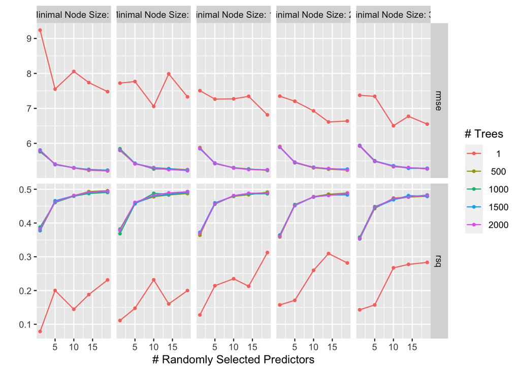

```r
# load the training result
load("model/rf.rda")

# plot the result
autoplot(rf_res)
```

```r
# show the best performing model
show_best(rf_res, metric = "rmse")
```

```
## # A tibble: 5 × 9
##    mtry trees min_n .metric .estimator  mean     n std_err .config
##   <int> <int> <int> <chr>   <chr>      <dbl> <int>   <dbl> <chr>
## 1    19   500     1 rmse    standard    5.21     5   0.176 Preprocessor1_Model0…
## 2    19  1000     8 rmse    standard    5.22     5   0.173 Preprocessor1_Model0…
## 3    19  2000     1 rmse    standard    5.22     5   0.164 Preprocessor1_Model0…
## 4    19   500    15 rmse    standard    5.22     5   0.155 Preprocessor1_Model0…
## 5    19  2000     8 rmse    standard    5.23     5   0.165 Preprocessor1_Model0…
```

```r
show_best(rf_res, metric = "rsq")
```

```
## # A tibble: 5 × 9
##    mtry trees min_n .metric .estimator  mean     n std_err .config
##   <int> <int> <int> <chr>   <chr>      <dbl> <int>   <dbl> <chr>
## 1    19   500     1 rsq     standard   0.496     5  0.0308 Preprocessor1_Model0…
## 2    19  2000     1 rsq     standard   0.494     5  0.0311 Preprocessor1_Model0…
## 3    19  1000     8 rsq     standard   0.493     5  0.0319 Preprocessor1_Model0…
## 4    19  1500     1 rsq     standard   0.493     5  0.0319 Preprocessor1_Model0…
## 5    14   500     1 rsq     standard   0.493     5  0.0317 Preprocessor1_Model0…
```

### K Nearest Neighbors (KNN)

We will fit a KNN model and tune `neighbors`.

```r
# KNN model
knn <- nearest_neighbor(mode = "regression", neighbors = tune()) %>%
  set_engine("kknn")

# create workflow by adding recipe and model
knn_workflow <- workflow() %>%
  add_recipe(nba_recipe) %>%
  add_model(knn)

# create tuning grid
knn_grid <- grid_regular(neighbors(range = c(1, 10)), levels = 5)

# fit models to folds
knn_res <- tune_grid(
  knn_workflow,
  resamples = nba_folds,
  grid = knn_grid
)
```

The fitting process takes some time, so we save the result:

```r
save(knn_res, knn_workflow, file = "model/knn.rda")
```

Assess the performance and select the best `penalty`:

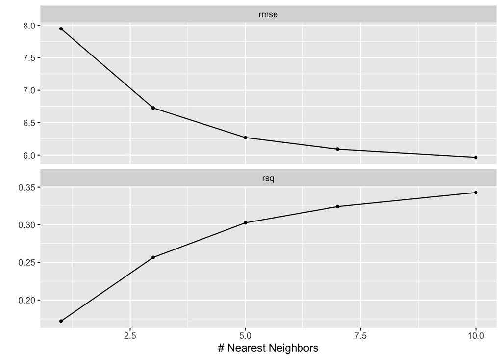

```r
# load the training result
load("model/knn.rda")

# plot the result
autoplot(knn_res)
```

```r
# show the best performing model
show_best(knn_res, metric = "rmse")
```

```
## # A tibble: 5 × 7
##   neighbors .metric .estimator  mean     n std_err .config
##       <int> <chr>   <chr>      <dbl> <int>   <dbl> <chr>
## 1        10 rmse    standard    5.96     5   0.266 Preprocessor1_Model5
## 2         7 rmse    standard    6.09     5   0.285 Preprocessor1_Model4
## 3         5 rmse    standard    6.27     5   0.314 Preprocessor1_Model3
## 4         3 rmse    standard    6.73     5   0.350 Preprocessor1_Model2
## 5         1 rmse    standard    7.95     5   0.453 Preprocessor1_Model1
```

```r
show_best(knn_res, metric = "rsq")
```

```
## # A tibble: 5 × 7
##   neighbors .metric .estimator  mean     n std_err .config
##       <int> <chr>   <chr>      <dbl> <int>   <dbl> <chr>
## 1        10 rsq     standard   0.343     5  0.0532 Preprocessor1_Model5
## 2         7 rsq     standard   0.324     5  0.0527 Preprocessor1_Model4
## 3         5 rsq     standard   0.302     5  0.0529 Preprocessor1_Model3
## 4         3 rsq     standard   0.257     5  0.0481 Preprocessor1_Model2
## 5         1 rsq     standard   0.172     5  0.0399 Preprocessor1_Model1
```

### The Best Model

```r
# finalize the model

# choose the best parameters of random forest model
best_rf <- select_best(rf_res)

# finalize workflow
rf_final <- finalize_workflow(rf_workflow, best_rf)
```

## Final Model

Since we already selected the model with the best performance after fitting all models and also finalized the model and workflow, we now fit the best model to the whole training set and evaluate the performance of our final model on the testing set.

### Fit to the Training Set

Fit the final model to the whole training set:

```r
# fit the final model to the training set:
final_fit <- fit(rf_final, data = nba_train)
```

Save the result:

```r
save(final_fit, file = "model/final_fit.rda")
```

### Performance on the Testing Set

```r
# load the finial fit
load("model/final_fit.rda")

# rmse on the testing set
augment(final_fit, new_data = nba_test) %>%
  rmse(truth = salary, estimate = .pred)
```

```
## # A tibble: 1 × 3
##   .metric .estimator .estimate
##   <chr>   <chr>          <dbl>
## 1 rmse    standard        2.36
```

```r
# rsq on the testing set
augment(final_fit, new_data = nba_test) %>%
  rsq(truth = salary, estimate = .pred)
```

```
## # A tibble: 1 × 3
##   .metric .estimator .estimate
##   <chr>   <chr>          <dbl>
## 1 rsq     standard       0.911
```

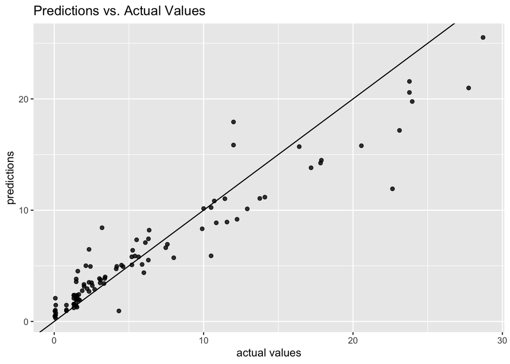

```r
# plot of predictions against actual values
augment(final_fit, new_data = nba_test) %>%
  ggplot(aes(salary, .pred)) +
  geom_abline() +
  geom_point(alpha = 0.8) +
  labs(title = "Predictions vs. Actual Values", x = "actual values", y = "predictions")
```

### Variable Importance

Now, we can take a look at the importance of predictors in predicting the salary.

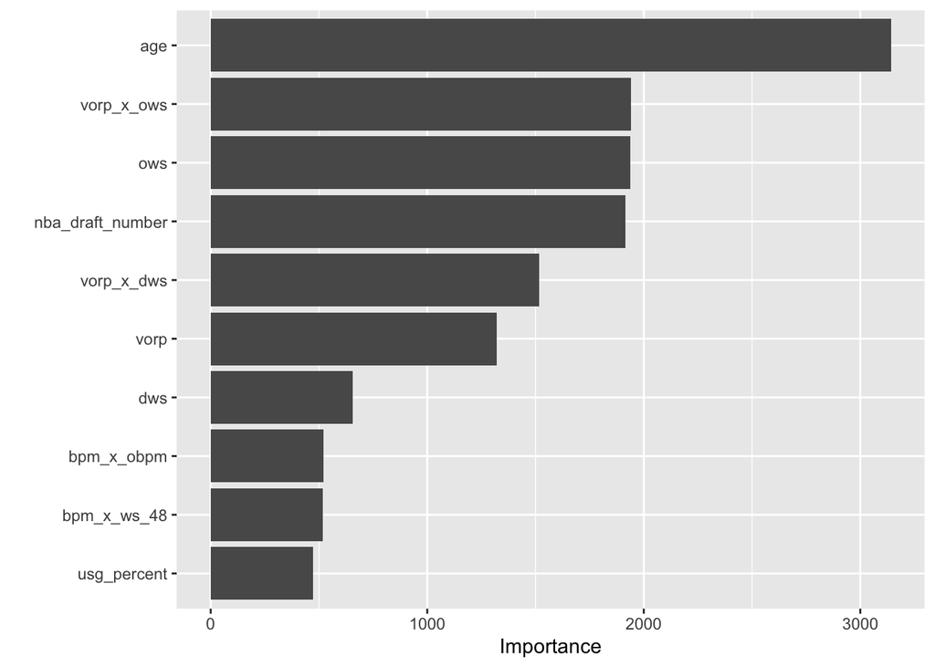

```r
final_fit %>%
  extract_fit_engine() %>%
  vip()
```

It is surprising for me that `age` is the most important predictor. Positive performance metrics are important as I expected, and draft number also plays an important role in predicting salary. Usage rate is not as that important as I expected.

### Check Several Players’ Predictions

In order to have a more direct view of the performance of the model, I will choose 3 NBA players who are 3 different levels.

#### LeBron James

```r
prediction <- augment(final_fit, new_data = nba_test)
prediction[prediction$player == "LeBron James", c("salary", ".pred")]
```

```
## # A tibble: 0 × 2
## # … with 2 variables: salary <dbl>, .pred <dbl>
```

#### Khris Middleton

The second player I chose is Khris Middleton, a starter level shooting guard of Milwaukee Bucks during the season 2017-18.

```r
prediction[prediction$player == "Khris Middleton", c("salary", ".pred")]
```

```
## # A tibble: 1 × 2
##   salary .pred
##    <dbl> <dbl>
## 1   14.1  11.2
```

#### Johnny O’Bryant

```r
prediction[prediction$player == "Johnny O'Bryant", c("salary", ".pred")]
```

```
## # A tibble: 0 × 2
## # … with 2 variables: salary <dbl>, .pred <dbl>
```

## Conclusion

During the analysis of the result, I realized that this is indeed a difficult problem. I always assumed that the salary of player is mostly correlated with his game performance, but it turns out that age plays the most important role. In future, I will perfect my this project from two directions. First, I will try to use a more complex machine learning model, such as neutral network. Second, I will try to find more data for salary prediction. For example, I plan to include the data of multiple seasons and also consider the influence of other potential variables.